# Visualisation du taux de criminalité en France en 2014

Hurgland-Nick KELIET

## R Markdown

Dans ce tutoriel, nous allons visualiser le taux de criminalité en France en 2014, et cela grâce à des librairies de R comme ggplot2, maps. Nous verrons également comment faire la jointure des données entre des données de géolocalisation contenant des données comme longitude et latitude, et un dataset contenant des valeurs que nous voulons faire apparaître dans notre cartographie.  
*prérequis*: S’y connaître en base de donnée pour comprendre les jointures.

### Importation des librairies

```r
# Dplyr, tidyr, etc....
library(tidyverse)
```

```r
# Visualisation
library(ggplot2)

# Cartographie
library(maps)
# palette de couleur
require(viridis)
```

### Création de la carte de France

- convertir des données d’une carte en Dataframe: map_data peut avoir comme paramètre (“France”, “usa”, “state”, “italy”, world“,”world2")
- map_data(map, region = “.”, exact = FALSE, …)
- la region peut être une liste précise comme : c(“departement_1”,“departement_2”,“departement_n”)

```r
region_france <- map_data("france")

# Visualisation des données de notre dataframe
str(region_france)
```

```
## 'data.frame':    13353 obs. of  6 variables:
##  $ long     : num  2.56 2.58 2.61 2.63 2.63 ...
##  $ lat      : num  51.1 51 51 51 50.9 ...
##  $ group    : num  1 1 1 1 1 1 1 1 1 1 ...
##  $ order    : int  1 2 3 4 5 6 7 8 9 10 ...
##  $ region   : chr  "Nord" "Nord" "Nord" "Nord" ...
##  $ subregion: chr  NA NA NA NA ...
```

### Visualisation des 10 premières lignes de notre dataframe

```r
head(region_france,10)
```

```
##        long      lat group order region subregion
## 1  2.557093 51.09752     1     1   Nord      <NA>
## 2  2.579995 51.00298     1     2   Nord      <NA>
## 3  2.609101 50.98545     1     3   Nord      <NA>
## 4  2.630782 50.95073     1     4   Nord      <NA>
## 5  2.625894 50.94116     1     5   Nord      <NA>
## 6  2.597699 50.91967     1     6   Nord      <NA>
## 7  2.602437 50.91389     1     7   Nord      <NA>
## 8  2.609284 50.90558     1     8   Nord      <NA>
## 9  2.615696 50.86754     1     9   Nord      <NA>
## 10 2.601085 50.85264     1    10   Nord      <NA>
```

### ggplot de notre carte

ggplot(world_map, aes(x = longitude, y = latitude, group = group)) + geom_polygon(fill =“red/lightgray/blue/etc”, colour = “colour”)

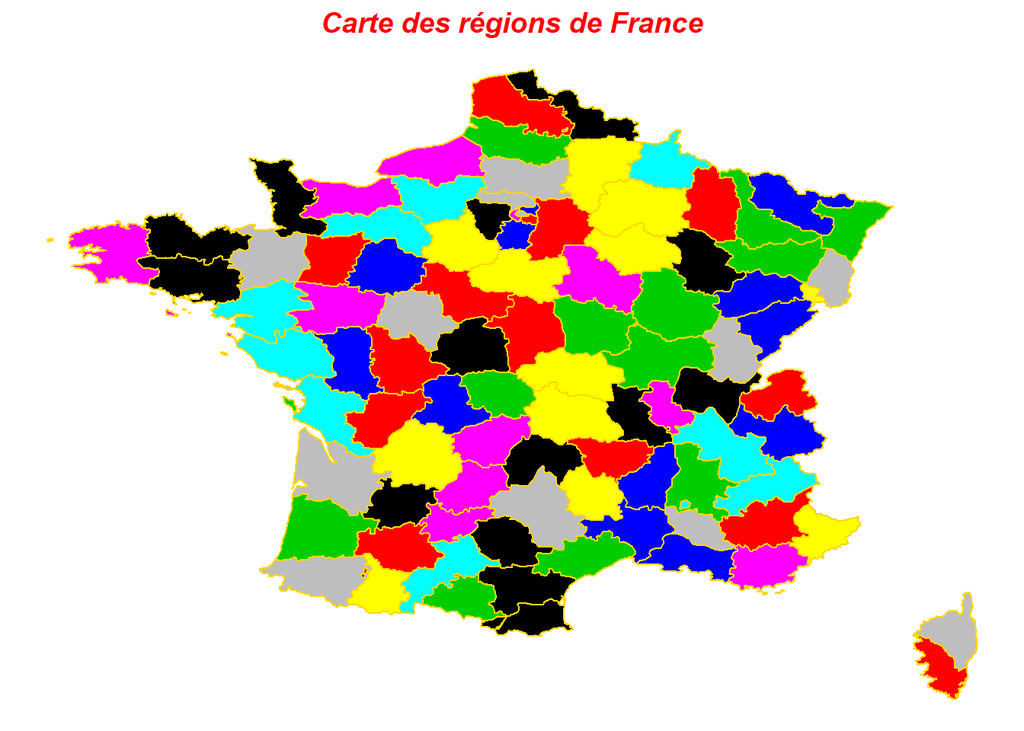

```r
# Affichons notre cartographie grâce à ggplot2
# theme_void() sert à enlever les graduations qui ne sont pas necessaires ici.
ggplot(region_france, aes(long, lat, group = group)) + theme_void() +

# Tracer les polygones
geom_polygon(fill = region_france$group, color = "gold1") +

# Donner un titre à la carte
ggtitle("Carte des régions de France") +

# Theme : Option de titre
# hjust <=> position sur l'axe horizontal
# hjust = 0, placer le titre à gauche
# hjust = 0.5, placer le titre au milieu
# hjust = 1, placer le titre à droite
theme(plot.title = element_text(color = "red", size = 14, face = "bold.italic", hjust = 0.5))
```

### Liste des régions présentes.

```r
sort(unique(region_france$region))
```

```
##  [1] "Ain"                     "Aisne"
##  [3] "Allier"                  "Alpes-de-Haute-Provence"
##  [5] "Alpes-Maritimes"         "Ardeche"
##  [7] "Ardennes"                "Ariege"
##  [9] "Aube"                    "Aude"
## [11] "Aveyron"                 "Bas-Rhin"
## [13] "Bouches-du-Rhone"        "Calvados"
## [15] "Cantal"                  "Charente"
## [17] "Charente-Maritime"       "Cher"
## [19] "Correze"                 "Corse du Sud"
## [21] "Cote-Dor"                "Cotes-Darmor"
## [23] "Creuse"                  "Deux-Sevres"
## [25] "Dordogne"                "Doubs"
## [27] "Drome"                   "Essonne"
## [29] "Eure"                    "Eure-et-Loir"
```

[output cut: 33 more lines]

### nombre total de régions

```r
length(unique(region_france$region))
```

```
## [1] 96
```

### Lisons sur les données contenant les classements des départements en France selon leur taux de criminalité en 2014 que j’ai téléchargé et traité dans un autre tutoriel.

Vous pourriez scrapper les données dans ce site [Wikipédia](https://fr.wikipedia.org/wiki/Taux_de_criminalit%C3%A9_en_France)

```r
# Mettre comme répertoire courant
setwd("~/R Project/Classement des départements selon leur taux de criminalité en 2014")

# chargeons le dataset sur la criminalité en France
criminalite <- read.csv("Départements _France_criminalité_2014.csv",sep = ';')
criminalite
```

```
##                      region criminalité..pourcentage.
## 1                       Ain                     37.41
## 2                     Aisne                     42.22
## 3                    Allier                     34.61
## 4   Alpes-de-Haute-Provence                     47.17
## 5           Alpes-Maritimes                     72.62
## 6                   Ardeche                     36.03
## 7                  Ardennes                     38.36
## 8                    Ariege                     40.31
## 9                      Aube                     50.84
## 10                     Aude                     47.69
## 11                  Aveyron                     26.44
## 12                 Bas-Rhin                     39.32
## 13         Bouches-du-Rhone                     76.51
## 14                 Calvados                     38.08
```

[output cut: 87 more lines]

### Affichons la structure de notre dataset .csv sur la criminalité

```r
str(criminalite)
```

```
## 'data.frame':    101 obs. of  2 variables:
##  $ region                   : Factor w/ 101 levels "Ain","Aisne",..: 1 2 3 4 5 6 7 8 9 10 ...
##  $ criminalité..pourcentage.: num  37.4 42.2 34.6 47.2 72.6 ...
```

### Effectuons la jointure entre notre dataset importé et ceux de la map.

```r
# merge(x = dataset_1, y = dataset_2, by = "colonne_commune")
# jointure des données par region
new_dataset_criminalite <- left_join(criminalite, region_france, by = "region")

# Affichons les 10 premières lignes
head(new_dataset_criminalite, 10)
```

```
##    region criminalité..pourcentage.     long      lat group order
## 1     Ain                     37.41 5.320572 46.44849    65  7403
## 2     Ain                     37.41 5.320681 46.42459    65  7404
## 3     Ain                     37.41 5.295058 46.38305    65  7405
## 4     Ain                     37.41 5.334702 46.37572    65  7406
## 5     Ain                     37.41 5.354812 46.36523    65  7407
## 6     Ain                     37.41 5.387390 46.33865    65  7408
## 7     Ain                     37.41 5.400368 46.31161    65  7409
## 8     Ain                     37.41 5.439684 46.30972    65  7410
## 9     Ain                     37.41 5.456065 46.29367    65  7411
## 10    Ain                     37.41 5.496184 46.27264    65  7412
##    subregion
## 1       <NA>
## 2       <NA>
## 3       <NA>
## 4       <NA>
## 5       <NA>
## 6       <NA>
## 7       <NA>
## 8       <NA>
## 9       <NA>
## 10      <NA>
```

```r
# Structure du nouveau dataset
str(new_dataset_criminalite)
```

```
## 'data.frame':    13358 obs. of  7 variables:
##  $ region                   : chr  "Ain" "Ain" "Ain" "Ain" ...
##  $ criminalité..pourcentage.: num  37.4 37.4 37.4 37.4 37.4 ...
##  $ long                     : num  5.32 5.32 5.3 5.33 5.35 ...
##  $ lat                      : num  46.4 46.4 46.4 46.4 46.4 ...
##  $ group                    : num  65 65 65 65 65 65 65 65 65 65 ...
##  $ order                    : int  7403 7404 7405 7406 7407 7408 7409 7410 7411 7412 ...
##  $ subregion                : chr  NA NA NA NA ...
```

# Affichons les cartes avec le taux de criminalité en 2014.

*map 1*

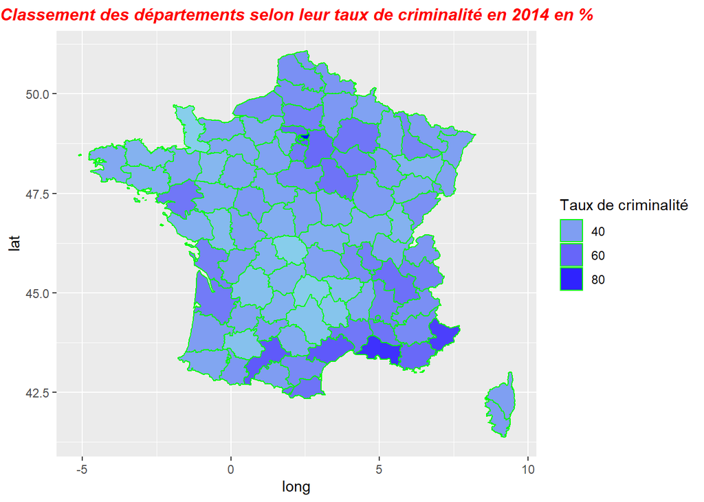

```r
#-------------------------------
# Première méthode avec gradient
#-------------------------------

if (require("maps")) {
# Paramétrons notre ggplot
ggplot(new_dataset_criminalite, aes(long, lat, group = group, fill = criminalité..pourcentage.)) +

# Renommer la légende
labs(fill = "Taux de criminalité") +

# Tracer les polygones
geom_polygon(color = "green") +

# Remplir avec le gradient
# Si nous voulons des valeurs entre 60 et 80, il suffira d'ajouter ci-dessous "limits = c(60,80)"
scale_fill_gradient(low = "skyblue", high = "blue", guide = "legend") +


# Donner un titre à la carte
ggtitle("Classement des départements selon leur taux de criminalité en 2014 en %") +

# Theme : Option de titre
theme(plot.title = element_text(color = "red", size = 12, face = "bold.italic", hjust = 0.5))
}
```

*map 2*

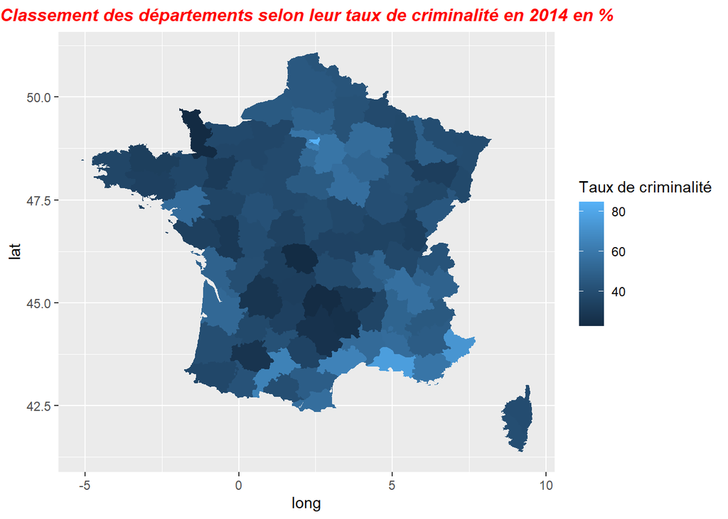

```r
#-------------------------------------------
# Deuxième méthode sans spécifier de couleur
#-------------------------------------------

if (require("maps")) {
# Jointure des données
jointure_data <- merge(criminalite, region_france, sort = FALSE, by = "region")
# Organiser les données
jointure_data <- jointure_data[order(jointure_data$order), ]

# ggplot
ggplot(jointure_data, aes(long, lat)) +
geom_polygon(aes(group = group, fill = criminalité..pourcentage.)) +
labs(fill = "Taux de criminalité") +
ggtitle("Classement des départements selon leur taux de criminalité en 2014 en %") +
theme(plot.title = element_text(color = "red", size = 12, face = "bold.italic", hjust = 0.5))
}
```

*map 3*

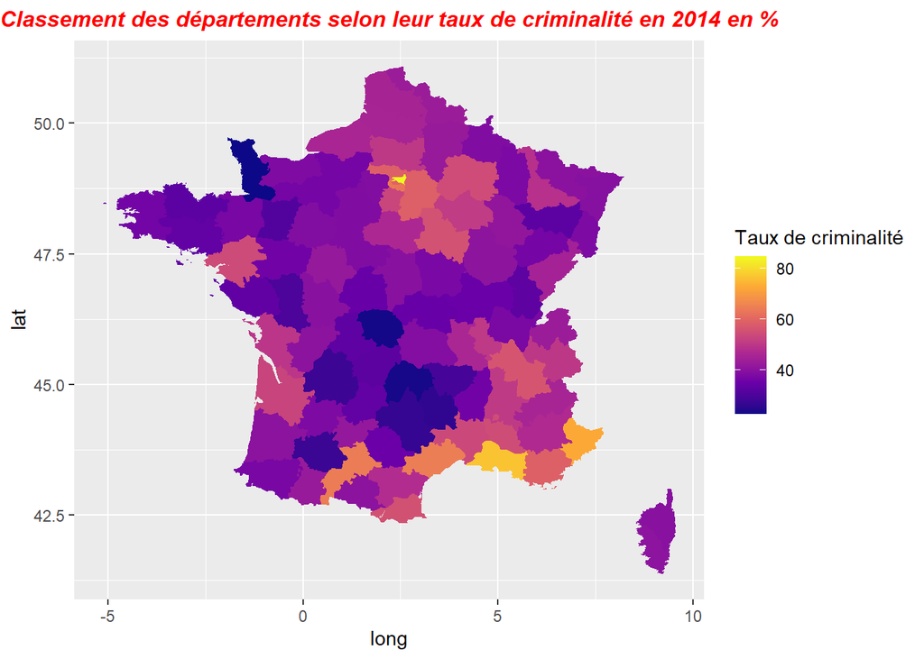

```r
#-------------------------------
# Troisième méthode avec viridis
#-------------------------------

if (require("maps")) {
# Jointure des données
jointure_data <- merge(criminalite, region_france, sort = FALSE, by = "region")
# Organiser les données
jointure_data <- jointure_data[order(jointure_data$order), ]

#ggplot
ggplot(jointure_data, aes(long, lat)) +
geom_polygon(aes(group = group, fill = criminalité..pourcentage.)) +
labs(fill = "Taux de criminalité") +
scale_fill_viridis_c(option = "C") +
ggtitle("Classement des départements selon leur taux de criminalité en 2014 en %") +
theme(plot.title = element_text(color = "red", size = 12, face = "bold.italic", hjust = 0.5))
}
```